```r
infn = "../data/Int Hypox Invitro and Human Meta Data.csv"
metadata = read.table(infn, sep=",", header=TRUE, stringsAsFactors=FALSE)
```

Here we make the coding for the variables easier to work with by making them smaller and removing spaces and other problem-causing characters. We will also make an ID that has the important metadata in it, to make plots easier to interpet.

```r
date2month = function(str) {
  month = months(as.Date(str, format="%m.%d.%y"))
  return(substring(month, 1, 3))
}

metadata$month = as.factor(unlist(lapply(metadata$Experiment.Date, date2month)))
metadata$line = as.factor(gsub(" ", "", metadata$Cell.Line))
metadata$spiked = as.factor(ifelse(grepl("No", metadata$Spike.In ), "nospike",
                                   "spike"))
metadata$hypoxia = as.factor(ifelse(grepl("Intermittent", metadata$Condition), "IH",
                             ifelse(grepl("Sustained", metadata$Condition), "SH",
                                    "NO")))
metadata$hypoxia = relevel(metadata$hypoxia, ref="NO")
metadata$filename = metadata$RCC.FILE.NAME
metadata$fullname = metadata$Full.Sample.Name
metadata$column = ifelse(grepl("Oligo", metadata$Column), "oligo",
                  ifelse(grepl("Reg", metadata$Column), "reg", "nocol"))
metadata$replicate = unlist(lapply(metadata$Replicate.Number,
                                   function(x) strsplit(as.character(x), "-")[[1]][2]))
metadata$id = as.character(paste(metadata$line, metadata$hypoxia, metadata$spiked,
                                 metadata$column, metadata$month, sep="_"))
metadata$id = ifelse(grepl("Blank", metadata$id), metadata$Full.Sample.Name,
                     metadata$id)
```

Now we are ready to roll and can read in the RCC files using the sweet `NanoStringQCPro` library. We’ll just read it in, extract the counts and then actually do the analysis with DESeq2.

```r
library(NanoStringQCPro)
rccFiles = paste("../data/rcc/", metadata[,"filename"], sep="")
#blanks = c("20160602_ES052616miRNAV3aC2_Blank_11.RCC", "20160602_ES052616miRNAV3aC2_Blank_12.RCC")
eset = newRccSet(rccFiles=rccFiles, blankLabel="Blank")
```

```
## Reading RCC files...
```

```
## checkRccSet() messages:
##   Optional featureData cols not found: BarCode, ProbeID, TargetSeq, Species, Comments
##   The following panel housekeeping genes were found: B2M|0, GAPDH|0, RPL19|0, ACTB|0, RPLP0|0
```

```r
pdata = pData(eset)
pdata$SampleType = metadata$line
pData(eset) <- pdata
proc = preprocRccSet(eset)
counts = as.data.frame(exprs(eset))
colnames(counts) = metadata$id
```

```r
is_positive = function(column) {
  return(grepl("Pos", column))
}
is_negative = function(column) {
  return(grepl("Neg", column))
}
is_spikein = function(column) {
  return(grepl("Spike", column))
}
is_ligation = function(column) {
  return(grepl("Ligati", column))
}
is_housekeeping = function(column) {
  return(grepl("Housekee", column))
}
is_prior = function(column) {
  return(grepl("miR-210", column) | grepl("miR-365", column))
}
```

## Scale miRNA with known crosstalk

A small set of miRNA have known inflated values; Nanostring has a heuristic to correct for the inflation via the formula using some supplied constants. Here we implement that fix to correct the expression of those miRNA.

```r
correct_miRNA = function(eset) {
  require(dplyr)
  fdat = fData(eset)
  fdat = fdat %>%
    tidyr::separate(GeneName, c("Name", "scalefactor"), sep='\\|',
                    fill="right", remove=FALSE) %>%
    dplyr::mutate(scalefactor=ifelse(is.na(scalefactor), 0, scalefactor))
  sf = as.numeric(fdat$scalefactor)
  posa = as.numeric(counts["Positive_POS_A_ERCC_00117.1",])
  scales = t(replicate(length(sf), posa))
  scales = scales * sf
  scaled = counts - scales
  scaled[scaled<0] = 0
  rownames(scaled) = fdat$Name
  return(round(scaled))
}

plot_corrected_miRNA = function(scaled, counts) {
  require(reshape)
  require(ggplot2)
  rownames(counts) = rownames(scaled)
  is_scaled = rowSums(abs(counts - scaled)) > 0
  counts = melt(as.matrix(counts[is_scaled,]))
  colnames(counts) = c("gene", "sample", "value")
  counts$scaled = "no"
  scaled = melt(as.matrix(scaled[is_scaled,]))
  colnames(scaled) = c("gene", "sample", "value")
  scaled$scaled = "yes"
  all = rbind(counts, scaled)
  library(cowplot)
  ggplot(all, aes(sample, value, color=scaled)) + facet_wrap(~gene) +
    geom_point(size=0.5) +
    theme(axis.title.x=element_blank(),
          axis.text.x=element_blank(),
          axis.ticks.x=element_blank(),
          strip.text.x=element_text(size=8)) +
    guides(colour = guide_legend(override.aes = list(size=6))) + ylab("") +
    ggtitle("miRNA hybridization crosstalk correction")
}
```

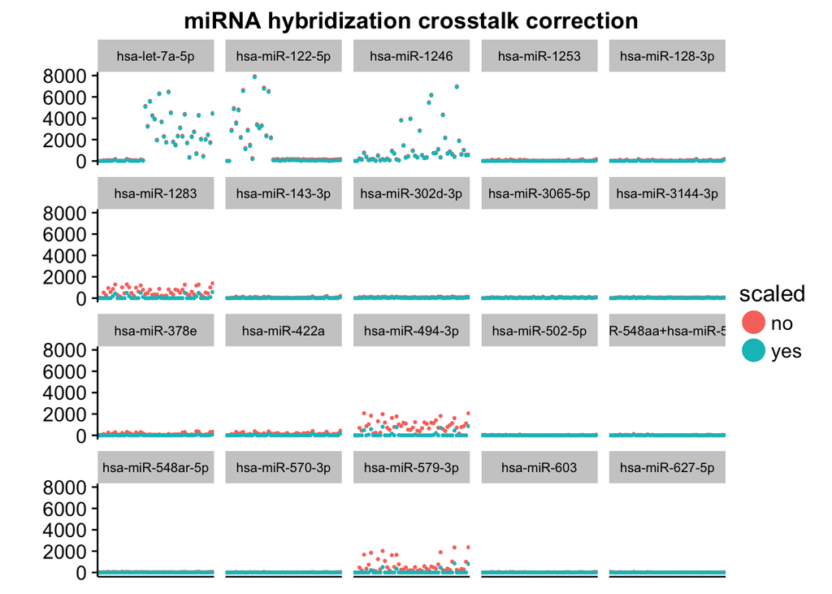

```r
scaled = correct_miRNA(eset)
plot_corrected_miRNA(scaled, counts)
```

## Positive controls

Positive controls look like some of them worked, and some of them didn’t.

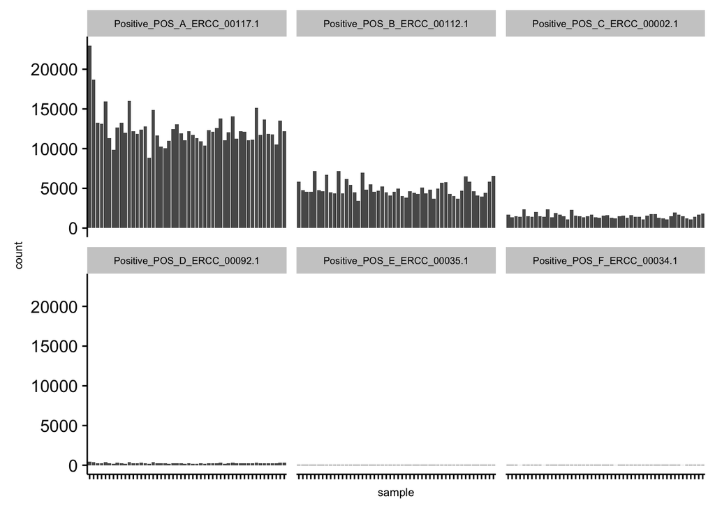

```r
library(ggplot2)
library(dplyr)
library(cowplot)

extract_pred = function(counts, predicate) {
  toplot = counts[predicate(rownames(counts)),] %>%
    tibble::rownames_to_column() %>%
    tidyr::gather("sample", "count", -rowname)
  colnames(toplot) = c("spot", "sample", "count")
  toplot = toplot %>% left_join(metadata, by=c("sample"="id"))
  return(toplot)
}
spotbarplot = function(toplot) {
  ggplot(toplot,
        aes(sample, count)) + geom_bar(stat='identity') +
    facet_wrap(~spot) +
    theme(axis.text.x = element_blank(),
          text = element_text(size=8))
}
spotboxplot = function(toplot) {
  ggplot(toplot,
        aes(linehypo, count)) + geom_boxplot() +
    facet_wrap(~spot) +
    theme(axis.text.x = element_text(angle = 90, hjust = 1))
}
spotbarplot(extract_pred(counts, is_positive))
```

## Negative controls

Negative counts can be relatively high in some of the samples compared to the other samples.

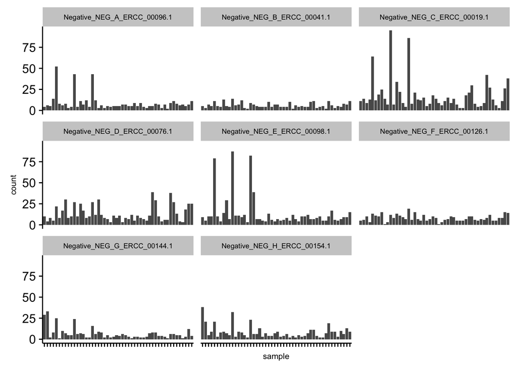

```r
spotbarplot(extract_pred(counts, is_negative))
```

It looks like all of those samples have something in common:

```r
knitr::kable(subset(extract_pred(counts, is_negative), count > 50))
```

|  | spot | sample | count | RCC.FILE.NAME | Full.Sample.Name | Cell.Line | Condition | What | Column | Spike.In | Experiment.Date | Replicate.Number | Date.Shipped | RCC.File.Date | month | line | spiked | hypoxia | filename | fullname | column | replicate |
| --- | --- | --- | --- | --- | --- | --- | --- | --- | --- | --- | --- | --- | --- | --- | --- | --- | --- | --- | --- | --- | --- | --- |
| 1 | Negative_NEG_C_ERCC_00019.1 | Huh7_IH_nospike_nocol_Jan | 64 | 20150421_PHS 1_01_10.RCC | IH1 | Huh 7 | Intermittent Hypoxia | Huh 7 cells Int Hypox | None | No spike in | 1.8.15 | H-1 | 4.6.15 | 4.21.2015 | Jan | Huh7 | nospike | IH | 20150421_PHS 1_01_10.RCC | IH1 | nocol | 1 |
| 3 | Negative_NEG_E_ERCC_00098.1 | Huh7_IH_nospike_nocol_Jan | 79 | 20150421_PHS 1_01_10.RCC | IH1 | Huh 7 | Intermittent Hypoxia | Huh 7 cells Int Hypox | None | No spike in | 1.8.15 | H-1 | 4.6.15 | 4.21.2015 | Jan | Huh7 | nospike | IH | 20150421_PHS 1_01_10.RCC | IH1 | nocol | 1 |
| 4 | Negative_NEG_A_ERCC_00096.1 | Huh7_IH_nospike_nocol_Jan | 52 | 20150421_PHS 1_01_10.RCC | IH1 | Huh 7 | Intermittent Hypoxia | Huh 7 cells Int Hypox | None | No spike in | 1.8.15 | H-1 | 4.6.15 | 4.21.2015 | Jan | Huh7 | nospike | IH | 20150421_PHS 1_01_10.RCC | IH1 | nocol | 1 |
| 9 | Negative_NEG_C_ERCC_00019.1 | Huh7_NO_nospike_nocol_Jan | 95 | 20150421_PHS 1_01_11.RCC | N1 | Huh 7 | Normoxia | Huh7 Normox | None | No spike in | 1.8.15 | H-1 | 4.6.15 | 4.21.2015 | Jan | Huh7 | nospike | NO | 20150421_PHS 1_01_11.RCC | N1 | nocol | 1 |
| 11 | Negative_NEG_E_ERCC_00098.1 | Huh7_NO_nospike_nocol_Jan | 87 | 20150421_PHS 1_01_11.RCC | N1 | Huh 7 | Normoxia | Huh7 Normox | None | No spike in | 1.8.15 | H-1 | 4.6.15 | 4.21.2015 | Jan | Huh7 | nospike | NO | 20150421_PHS 1_01_11.RCC | N1 | nocol | 1 |
| 17 | Negative_NEG_C_ERCC_00019.1 | Huh7_SH_nospike_nocol_Jan | 86 | 20150421_PHS 1_01_12.RCC | SH1 | Huh 7 | Sustained Hypoxia | Huh7 Sust Hypox | None | No spike in | 1.8.15 | H-1 | 4.6.15 | 4.21.2015 | Jan | Huh7 | nospike | SH | 20150421_PHS 1_01_12.RCC | SH1 | nocol | 1 |
| 19 | Negative_NEG_E_ERCC_00098.1 | Huh7_SH_nospike_nocol_Jan | 82 | 20150421_PHS 1_01_12.RCC | SH1 | Huh 7 | Sustained Hypoxia | Huh7 Sust Hypox | None | No spike in | 1.8.15 | H-1 | 4.6.15 | 4.21.2015 | Jan | Huh7 | nospike | SH | 20150421_PHS 1_01_12.RCC | SH1 | nocol | 1 |

Was anything different about those samples?

## SpikeIn

It looks like there are some samples that have spike-ins

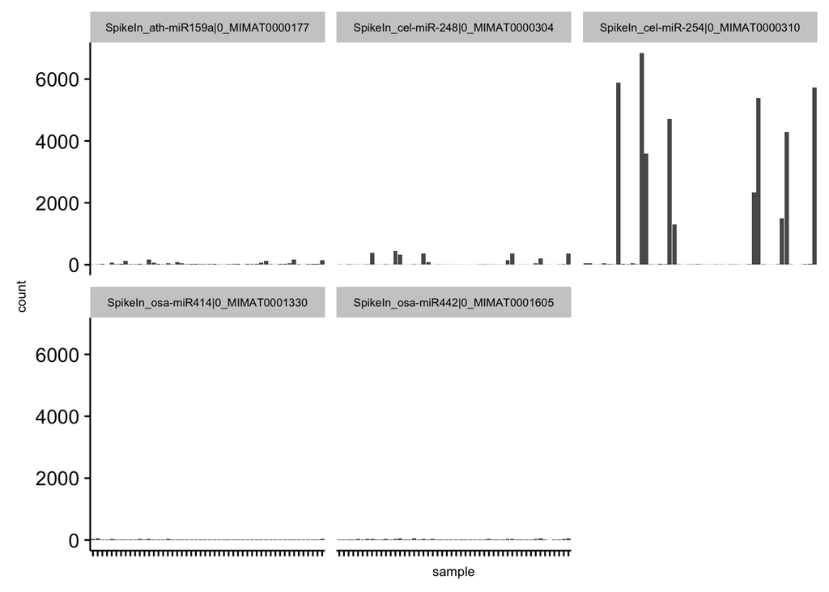

```r
spotbarplot(extract_pred(counts, is_spikein))
```

And those correspond to the spike-ins in the metadata:

```r
knitr::kable(subset(extract_pred(counts, is_spikein), count > 500))
```

|  | spot | sample | count | RCC.FILE.NAME | Full.Sample.Name | Cell.Line | Condition | What | Column | Spike.In | Experiment.Date | Replicate.Number | Date.Shipped | RCC.File.Date | month | line | spiked | hypoxia | filename | fullname | column | replicate |
| --- | --- | --- | --- | --- | --- | --- | --- | --- | --- | --- | --- | --- | --- | --- | --- | --- | --- | --- | --- | --- | --- | --- |
| 18 | SpikeIn_cel-miR-254\|0_MIMAT0000310 | U937_NO_spike_nocol_Oct | 4287 | 20151118_Espy-11-18-15-rescan_01_07.RCC | UN | U937 | Normoxia | U937 Normox | None | + Spike In | 10.27.15 | U-1 | 10.28.15 | 11.15.15 | Oct | U937 | spike | NO | 20151118_Espy-11-18-15-rescan_01_07.RCC | UN | nocol | 1 |
| 23 | SpikeIn_cel-miR-254\|0_MIMAT0000310 | U937_IH_spike_nocol_Oct | 5390 | 20151118_Espy-11-18-15-rescan_01_08.RCC | UIH | U937 | Intermittent Hypoxia | U937 Int Hypox | None | + Spike In | 10.27.15 | U-1 | 10.28.15 | 11.15.15 | Oct | U937 | spike | IH | 20151118_Espy-11-18-15-rescan_01_08.RCC | UIH | nocol | 1 |
| 28 | SpikeIn_cel-miR-254\|0_MIMAT0000310 | U937_SH_spike_nocol_Oct | 5733 | 20151118_Espy-11-18-15-rescan_01_09.RCC | USH | U937 | Sustained Hypoxia | U937 Sust Hypx | None | + Spike In | 10.27.15 | U-1 | 10.28.15 | 11.15.15 | Oct | U937 | spike | SH | 20151118_Espy-11-18-15-rescan_01_09.RCC | USH | nocol | 1 |
| 33 | SpikeIn_cel-miR-254\|0_MIMAT0000310 | Huh7_NO_spike_nocol_Oct | 6840 | 20151118_Espy-11-18-15-rescan_01_10.RCC | H7N | Huh 7 | Normoxia | Huh 7 Normox | None | + Spike In | 10.27.15 | H-2 | 10.28.15 | 11.15.15 | Oct | Huh7 | spike | NO | 20151118_Espy-11-18-15-rescan_01_10.RCC | H7N | nocol | 2 |
| 38 | SpikeIn_cel-miR-254\|0_MIMAT0000310 | Huh7_IH_spike_nocol_Oct | 5883 | 20151118_Espy-11-18-15-rescan_01_11.RCC | H7IH | Huh 7 | Intermittent Hypoxia | Huh 7 Int Hypox | None | + Spike In | 10.27.15 | H-2 | 10.28.15 | 11.15.15 | Oct | Huh7 | spike | IH | 20151118_Espy-11-18-15-rescan_01_11.RCC | H7IH | nocol | 2 |
| 43 | SpikeIn_cel-miR-254\|0_MIMAT0000310 | Huh7_SH_spike_nocol_Oct | 4708 | 20151118_Espy-11-18-15-rescan_01_12.RCC | H7SH | Huh 7 | Sustained Hypoxia | Huh 7 Sust hypox | None | + Spike In | 10.27.15 | H-2 | 10.28.15 | 11.15.15 | Oct | Huh7 | spike | SH | 20151118_Espy-11-18-15-rescan_01_12.RCC | H7SH | nocol | 2 |
| 48 | SpikeIn_cel-miR-254\|0_MIMAT0000310 | U937_NO_spike_nocol_Jan | 1501 | 20160114_ES011416miRNAV3a_U937 N_01.RCC | UN | U937 | Normoxia | U937 Normox | None | + Spike In | 1.3.16 | U-2 | 1.4.16 | 1.20.16 | Jan | U937 | spike | NO | 20160114_ES011416miRNAV3a_U937 N_01.RCC | UN | nocol | 2 |
| 53 | SpikeIn_cel-miR-254\|0_MIMAT0000310 | U937_IH_spike_nocol_Jan | 2333 | 20160114_ES011416miRNAV3a_U937 IH_02.RCC | UIH | U937 | Intermittent Hypoxia | U937 Int Hypox | None | + Spike In | 1.3.16 | U-2 | 1.4.16 | 1.20.16 | Jan | U937 | spike | IH | 20160114_ES011416miRNAV3a_U937 IH_02.RCC | UIH | nocol | 2 |
| 63 | SpikeIn_cel-miR-254\|0_MIMAT0000310 | Huh7_NO_spike_oligo_Jan | 3587 | 20160114_ES011416miRNAV3a_H7 Nor5m_04.RCC | HN9 | Huh 7 | Normoxia | Huh 7 Normox | Oligo | + Spike In | 1.3.16 | H-3 | 1.4.16 | 1.20.16 | Jan | Huh7 | spike | NO | 20160114_ES011416miRNAV3a_H7 Nor5m_04.RCC | HN9 | oligo | 3 |
| 73 | SpikeIn_cel-miR-254\|0_MIMAT0000310 | Huh7_SH_spike_reg_Jan | 1308 | 20160114_ES011416miRNAV3a_H7 SH_06.RCC | HSHR | Huh 7 | Sustained Hypoxia | Huh 7 Sust hypox | Regular | +Spike IN | 1.3.16 | H-3 | 1.4.16 | 1.20.16 | Jan | Huh7 | spike | SH | 20160114_ES011416miRNAV3a_H7 SH_06.RCC | HSHR | reg | 3 |

They are all from October and January though. Is the metadata not correct about the spike ins for these samples?

## Ligation

Only some of the ligation controls show up

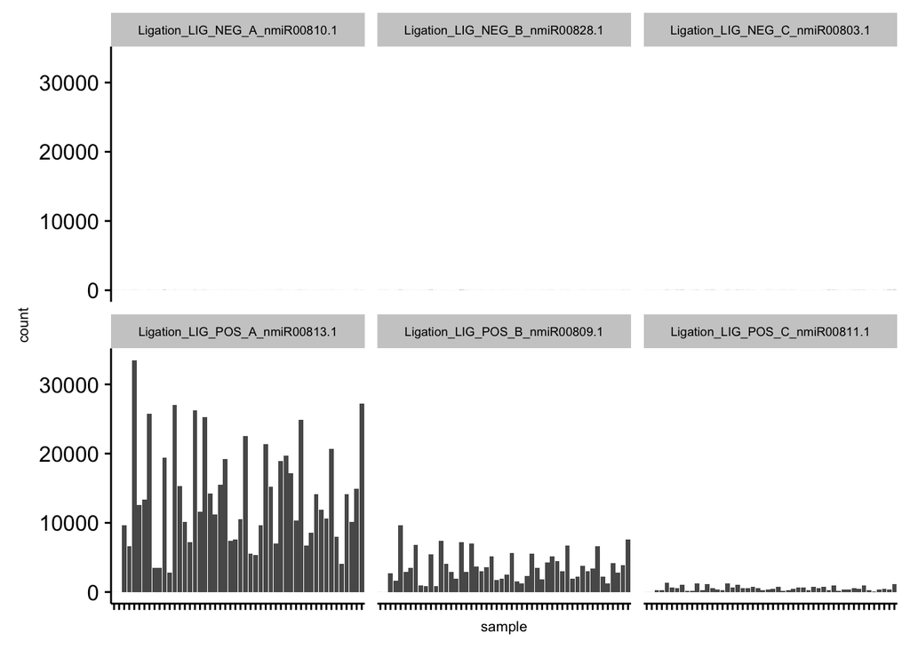

```r
spotbarplot(extract_pred(counts, is_ligation))
```

## Housekeeping

For a subset of the samples, one housekeeping gene is very high.

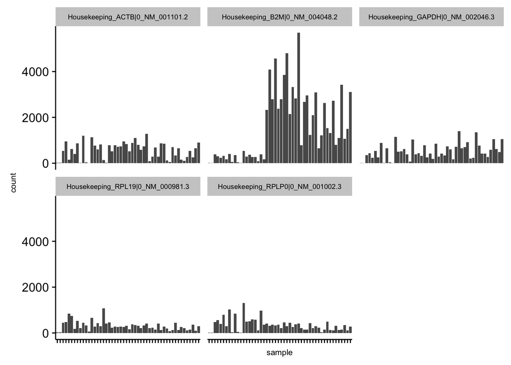

```r
spotbarplot(extract_pred(counts, is_housekeeping))
```

These don’t look confined to any particular cell type. Why are some of these so different?

```r
table(subset(extract_pred(counts, is_housekeeping), count > 1000)$sample)
```

```
##
##   Huh7_IH_spike_nocol_Oct Huh7_NO_nospike_nocol_Dec
##                         1                         1
##   Huh7_NO_spike_nocol_Oct Huh7_SH_nospike_nocol_Jan
##                         3                         1
##   Huh7_SH_spike_nocol_Oct  THP_IH_nospike_nocol_Aug
##                         1                         1
##  THP_IH_nospike_nocol_Dec  THP_IH_nospike_nocol_Jul
##                         1                         1
##  THP_IH_nospike_nocol_Sep  THP_NO_nospike_nocol_Aug
##                         1                         1
##  THP_NO_nospike_nocol_Dec  THP_NO_nospike_nocol_Jul
##                         1                         1
##  THP_NO_nospike_nocol_Sep  THP_SH_nospike_nocol_Aug
##                         2                         1
##  THP_SH_nospike_nocol_Dec  THP_SH_nospike_nocol_Jul
##                         1                         1
##  THP_SH_nospike_nocol_Sep U937_IH_nospike_nocol_Aug
##                         2                         1
## U937_IH_nospike_nocol_Jul U937_IH_nospike_nocol_Nov
##                         2                         1
##   U937_IH_spike_nocol_Jan   U937_IH_spike_nocol_Oct
##                         1                         1
## U937_NO_nospike_nocol_Aug U937_NO_nospike_nocol_Jul
##                         1                         2
## U937_NO_nospike_nocol_Nov   U937_NO_spike_nocol_Jan
##                         1                         1
##   U937_NO_spike_nocol_Oct U937_SH_nospike_nocol_Aug
##                         1                         1
## U937_SH_nospike_nocol_Jul U937_SH_nospike_nocol_Nov
##                         2                         1
##   U937_SH_spike_nocol_Jan   U937_SH_spike_nocol_Oct
##                         1                         2
```

## Drop non-negative control and housekeeping

```r
keep = counts[!(is_spikein(rownames(counts)) | is_positive(rownames(counts)) |
                is_housekeeping(rownames(counts)) | is_ligation(rownames(counts))),]
keep = counts[, !grepl("Blank", colnames(counts))]
metadata = subset(metadata, id %in% colnames(keep))
counts = keep
```

## Drop genes below noise floor

We’ll normalize the libraries and look at the negative control expression and then come up with a cutoff that is above the noise floor for the libraries.

```r
library(DESeq2)
dds = DESeqDataSetFromMatrix(keep, colData=metadata, design=~month+column+line+hypoxia)
```

```
## factor levels were dropped which had no samples
```

```r
dds = estimateSizeFactors(dds)
ncounts = data.frame(counts(dds, normalized=TRUE))
```

Below we can see after normalizing by library size, if we set the cutoff to be 30, we are mostly above the noise floor measured by the negative controls:

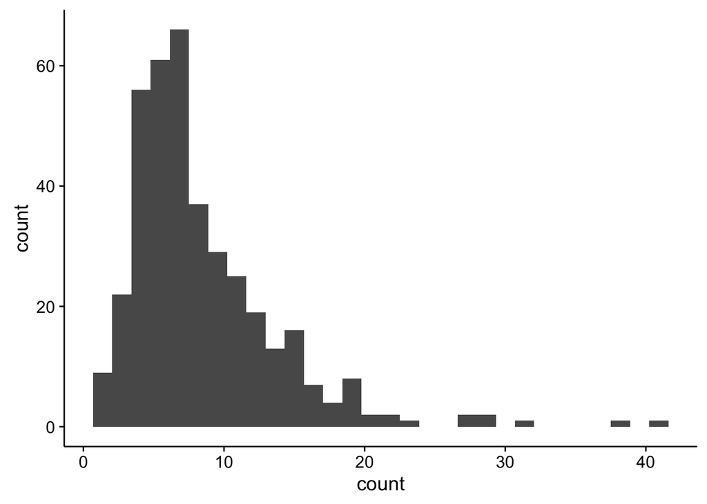

```r
ggplot(extract_pred(ncounts, is_negative), aes(count)) + geom_histogram()
```

We used the threshold of 30 as the noise floor and dropped all" miRNA that did not have at least 30 counts in 20% of the samples.

```r
keepgenes = ncounts[rowSums(ncounts > 30) > 0.2*ncol(ncounts),]
```

This left us with 149 miRNA to consider out of the original 828.

## Differential expression

```r
dds = DESeqDataSetFromMatrix(counts[rownames(keep),colnames(keep)], colData=metadata,
                             design=~column+spiked+line+hypoxia)
```

```
## factor levels were dropped which had no samples
```

```r
dds = DESeq(dds, fitType='local')
```

Nanostring data has an opposite mean-variance relationship than RNA-seq data. Here the dispersion is slightly higher for more highly expressed miRNA– the the trend is mostly flat, however.

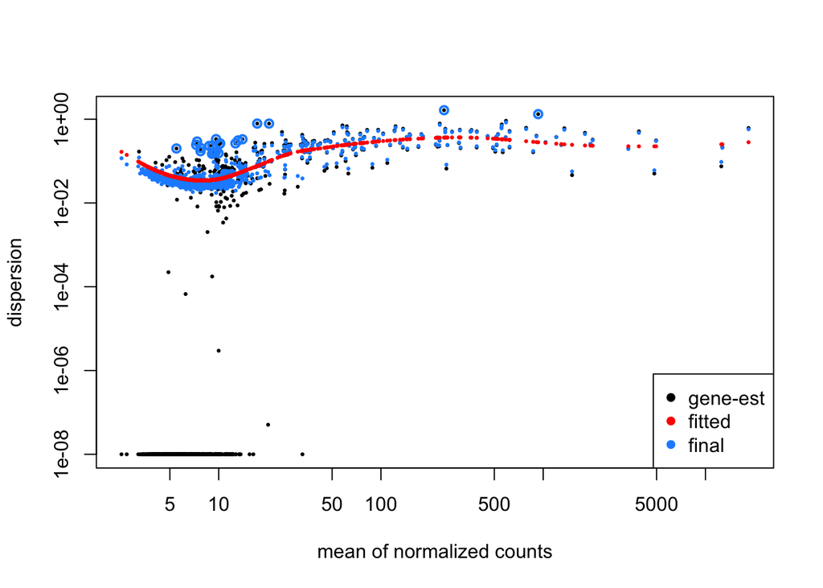

```r
plotDispEsts(dds)
```

## Cell line differences

### Huh7 vs U937

```r
res = results(dds, contrast=c("line", "Huh7", "U937"))
```

### Huh7 vs THP

```r
res = results(dds, contrast=c("line", "Huh7", "THP"))
```

### THP vs U937

```r
res = results(dds, contrast=c("line", "THP", "U937"))
```

## Hypoxic state differences

### Normal vs intermittent

```r
res = results(dds, contrast=c("hypoxia", "NO", "IH"))
```

### Intermittent vs sustained

```r
res = results(dds, contrast=c("hypoxia", "IH", "SH"))
```

### Normal vs sustained

```r
res = results(dds, contrast=c("hypoxia", "NO", "SH"))
```

## Cell line specific hypoxic state differences

Here we refit the model with a new factor that is a combination of cell line and hypoxic state. Then we test if there are differences between the hypoxic states within each cell line.

```r
metadata$linehypo = paste(metadata$line, metadata$hypoxia, sep="_")
dds = DESeqDataSetFromMatrix(counts[rownames(keepgenes),], colData=metadata,
                             design=~column+spiked+linehypo)
dds = DESeq(dds, fitType='local')
```

### THP

We can se that the overall fold changes are fairly small relative to the standard error of the fold changes. Signal to noise ratio here is combined as the log fold change divided by the log fold change standard error.

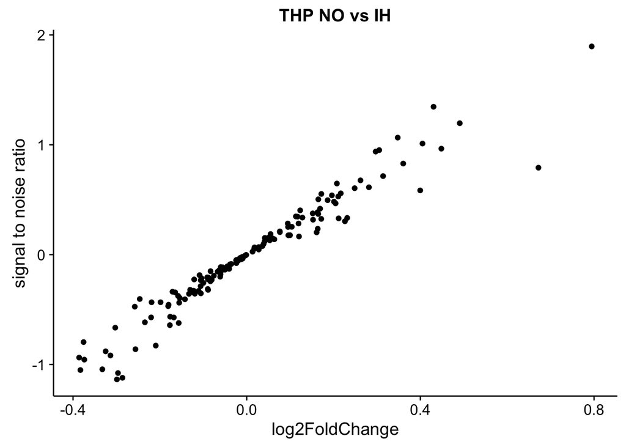

```r
write_results = function(res, fname) {
  res = data.frame(res) %>% tibble::rownames_to_column() %>%
    arrange(pvalue)
  write.table(res, file=fname, quote=FALSE, col.names=TRUE,
              row.names=FALSE, sep=",")
}

res = results(dds, contrast=c("linehypo", "THP_NO", "THP_IH"), addMLE=TRUE)
ggplot(data.frame(res), aes(log2FoldChange, lfcMLE/lfcSE)) + geom_point() +
  ylab("signal to noise ratio") + ggtitle("THP NO vs IH")
```

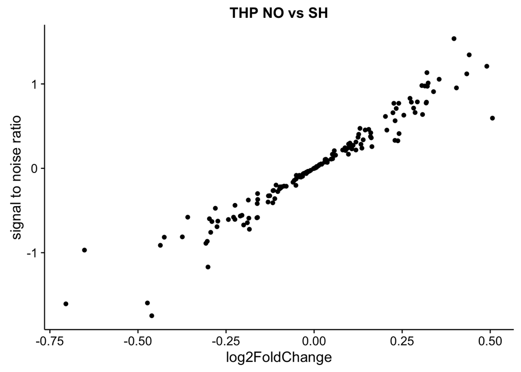

```r
write_results(res, "THP_NOvsIH.csv")
res = results(dds, contrast=c("linehypo", "THP_NO", "THP_SH"), addMLE=TRUE)
ggplot(data.frame(res), aes(log2FoldChange, lfcMLE/lfcSE)) + geom_point() +
  ylab("signal to noise ratio") + ggtitle("THP NO vs SH")
```

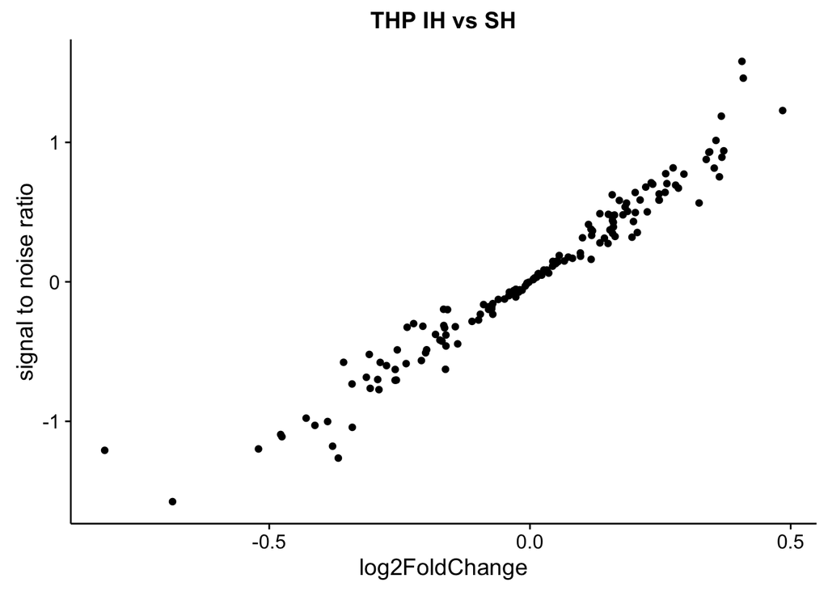

```r
write_results(res, "THP_NOvsSH.csv")
res = results(dds, contrast=c("linehypo", "THP_IH", "THP_SH"), addMLE=TRUE)
ggplot(data.frame(res), aes(log2FoldChange, lfcMLE/lfcSE)) + geom_point() +
  ylab("signal to noise ratio") + ggtitle("THP IH vs SH")
```

```r
write_results(res, "THP_IHvsSH.csv")
```

### Huh7

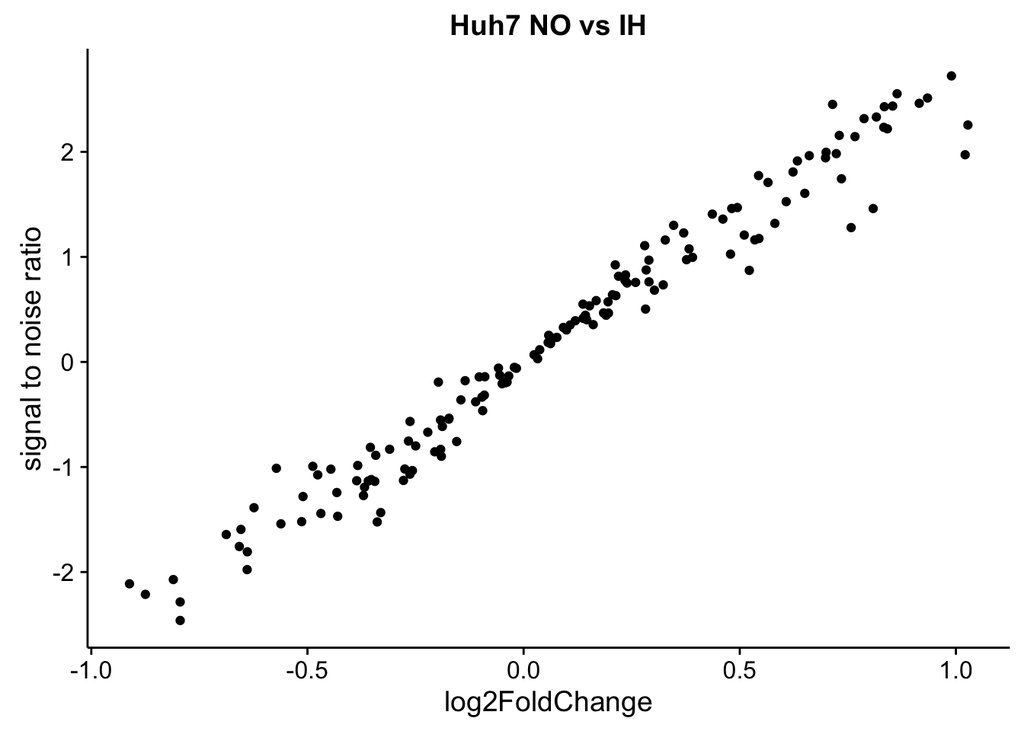

```r
res = results(dds, contrast=c("linehypo", "Huh7_NO", "Huh7_IH"), addMLE=TRUE)
ggplot(data.frame(res), aes(log2FoldChange, lfcMLE/lfcSE)) + geom_point() +
  ylab("signal to noise ratio") + ggtitle("Huh7 NO vs IH")
```

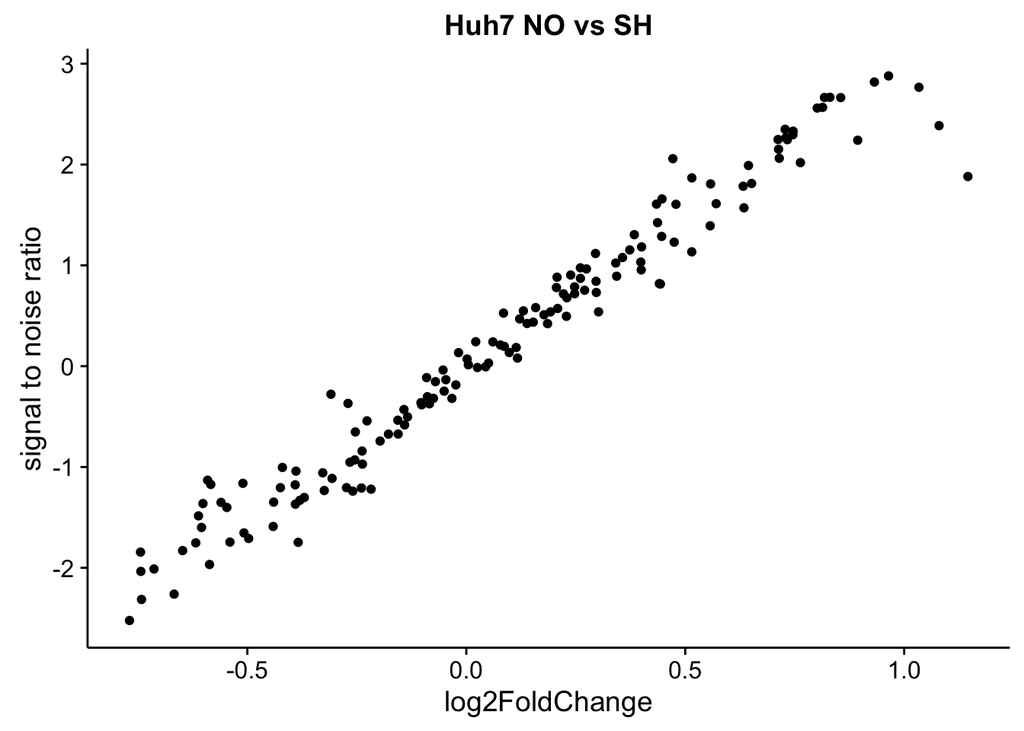

```r
write_results(res, "Huh7_NOvsIH.csv")
res = results(dds, contrast=c("linehypo", "Huh7_NO", "Huh7_SH"), addMLE=TRUE)
ggplot(data.frame(res), aes(log2FoldChange, lfcMLE/lfcSE)) + geom_point() +
  ylab("signal to noise ratio") + ggtitle("Huh7 NO vs SH")
```

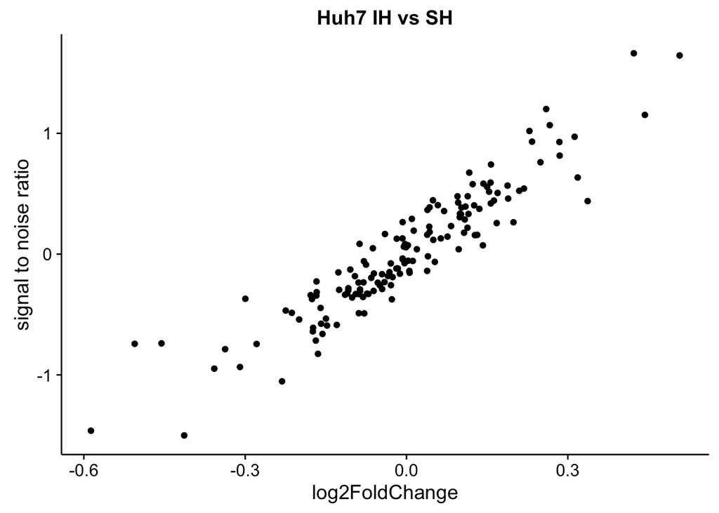

```r
write_results(res, "Huh7_NOvsSH.csv")
res = results(dds, contrast=c("linehypo", "Huh7_IH", "Huh7_SH"), addMLE=TRUE)
ggplot(data.frame(res), aes(log2FoldChange, lfcMLE/lfcSE)) + geom_point() +
  ylab("signal to noise ratio") + ggtitle("Huh7 IH vs SH")
```

```r
write_results(res, "Huh7_IHvsSH.csv")
```

### U937

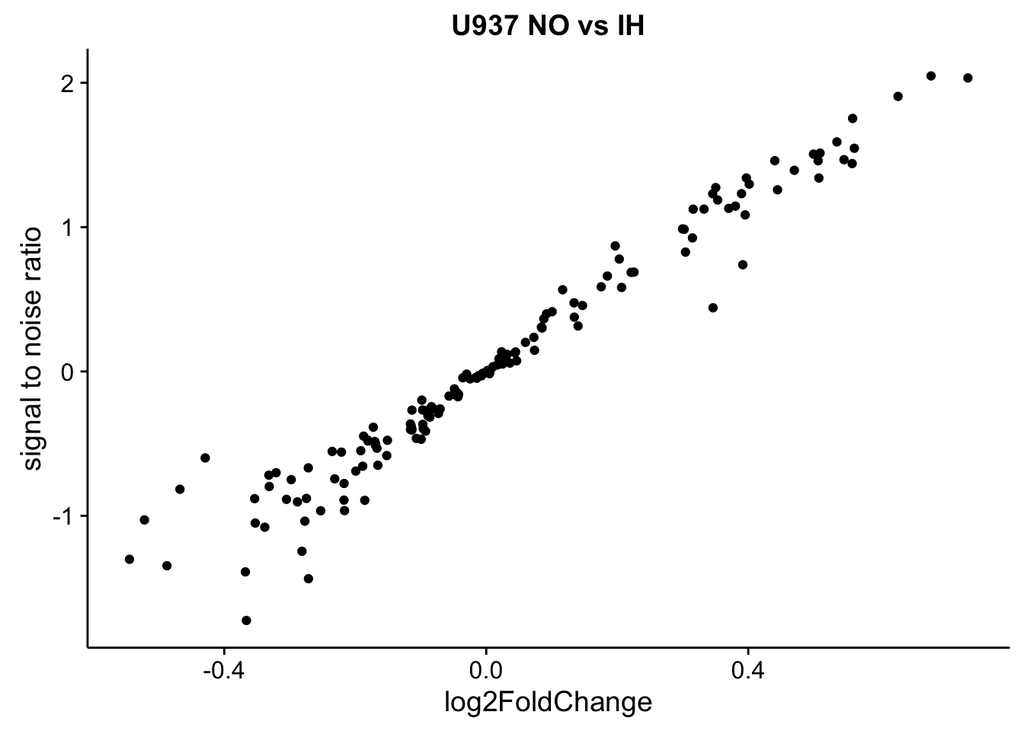

```r
res = results(dds, contrast=c("linehypo", "U937_NO", "U937_IH"), addMLE=TRUE)
ggplot(data.frame(res), aes(log2FoldChange, lfcMLE/lfcSE)) + geom_point() +
  ylab("signal to noise ratio") + ggtitle("U937 NO vs IH")
```

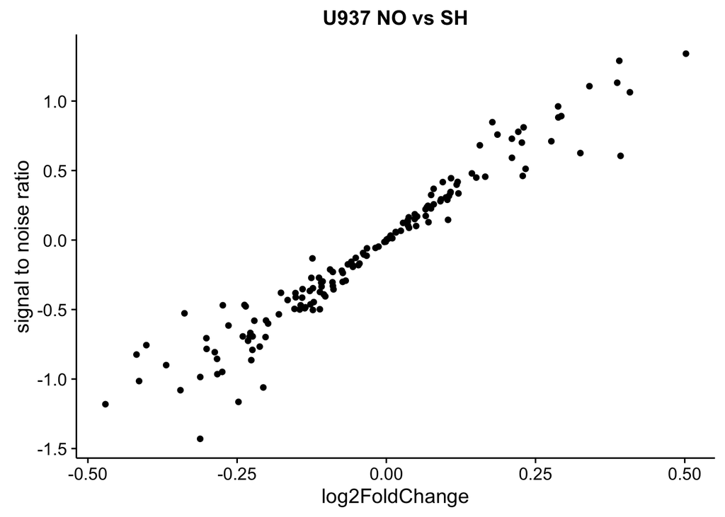

```r
write_results(res, "U937_NOvsIH.csv")
res = results(dds, contrast=c("linehypo", "U937_NO", "U937_SH"), addMLE=TRUE)
ggplot(data.frame(res), aes(log2FoldChange, lfcMLE/lfcSE)) + geom_point() +
  ylab("signal to noise ratio") + ggtitle("U937 NO vs SH")
```

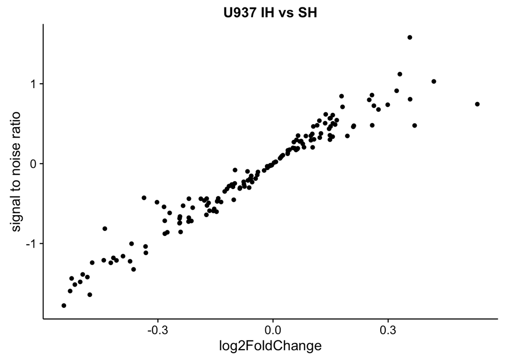

```r
write_results(res, "U937_NOvsSH.csv")
res = results(dds, contrast=c("linehypo", "U937_IH", "U937_SH"), addMLE=TRUE)
ggplot(data.frame(res), aes(log2FoldChange, lfcMLE/lfcSE)) + geom_point() +
  ylab("signal to noise ratio") + ggtitle("U937 IH vs SH")
```

```r
write_results(res, "U937_IHvsSH.csv")
```

# Prior miRNA

miR-210 is below the noise floor– one of the miR-365 spots though has higher expression values.

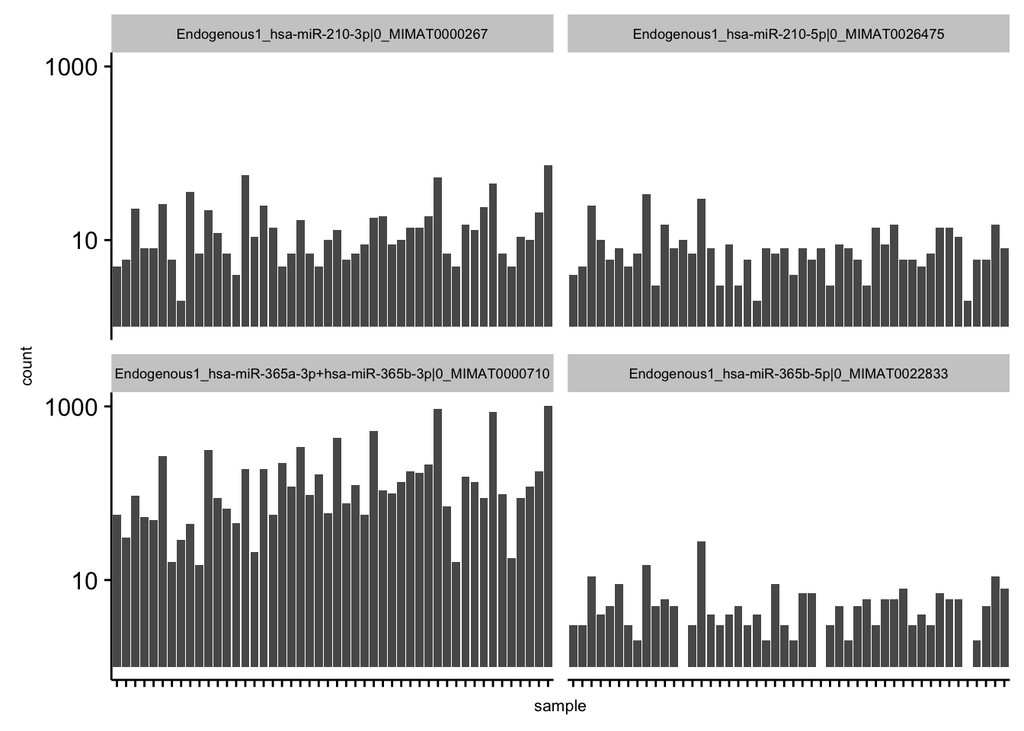

```r
spotbarplot(extract_pred(counts, is_prior)) + scale_y_log10()
```

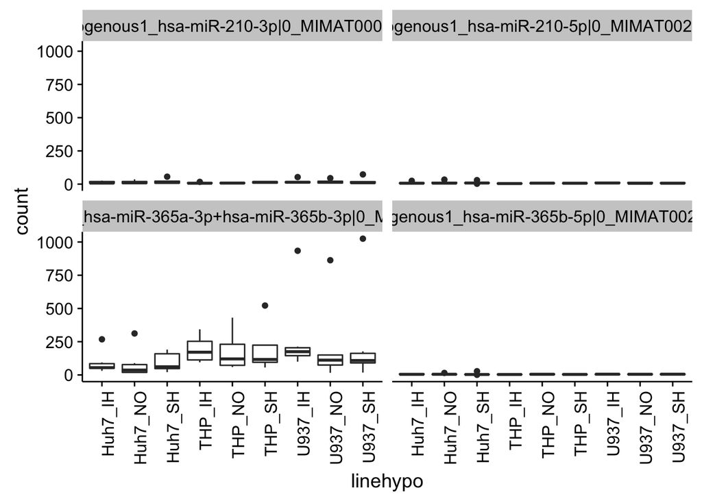

```r
spotboxplot(extract_pred(counts, is_prior))
```